# Statistical inference with the GSS data

## Setup

Load the required packages and the data.

```r
library(ggplot2)
library(dplyr)
library(statsr)
```

```r
load("gss.Rdata")
```

## 1. Data

### 1.1 Background

The General Society Survey (GSS) is conducted by the National Opinion Research Center (NORC), which affiliated with the University of Chicago. It was started in 1972. The objectives of the survey are to act as a functioning social indicator program and to provide high quality, fresh data regarding the U.S. society to the public, policy makers, and other organizations.

The types of data reflect the attitudes, attributes, and behaviors regarding the structure and the functioning of the United States society.

### 1.2 Data Collection

The data is generally collected through face-to-face interviews of median duration of about 1.5 hours. If the respondent prefers, the survey can be conducted through the phone. Owing to the covid-19 pandemic, in 2020, the survey was fully online.

The questions on the survey are of three types: permanent, rotating, and occasional questions. Rotating questions appear on two our of three surveys. However, after 1988, rotating questions were included in two thirds of all surveys each year.

### 1.3 Sampling Scope

The household addresses of the respondents are selected in a random manner so that every address in the U.S. has an equal probability of being selected for the survey. From each household, a random person above 18 years of age is chosen as the respondent. Therefore, this is **random sampling**. As a result, the findings of the survey and any inferences based on those findings can be **generalized** to the population (i.e. the U.S. population).

As this is a survey and not an experiment, there is **No** random assignment. Therefore, causal relationships **cannot** be inferred. However, the study is **correlational**.

#### 1.3.1 Sampling Biases

Most working people would not have about 1.5 hours to sit and talk to a survey taker. Therefore, the samples might be biased towards un-employed people, older people or housewives.

## 2. Research Question

Is there any difference between gun ownership in the U.S. before and after the year 2001? In other words, might there be a relationship between the proportion of U.S. citizens that owned a gun and the year being pre- or post- 2001?

The variables of interest are:  
**year**: GSS year for this respondent.  
**owngun**: Do you happen to have in your home (or garage) any guns or revolvers?

**Rationale for the research question**: In the year 2001, 9/11 took place. This might have lead some U.S. citizens to feel unsafe and might have persuaded them to buy a gun.

## 3. Exploratory Data Analysis

Both the variables **year** and **owngun** are categorical. For **year**, the interested levels are 2000 and 2002. Year 2000 represents the pre 9/11 and 2002 represents post 9/11.

```r
projData <- gss %>% select(year, owngun) %>%
  filter(year == 2000 | year == 2002)

# Let us look at the structure of this data.
projData %>% group_by(year, owngun) %>% summarise(n())
```

```
## # A tibble: 8 x 3
## # Groups:   year [2]
##    year owngun  `n()`
##   <int> <fct>   <int>
## 1  2000 Yes       603
## 2  2000 No       1231
## 3  2000 Refused    23
## 4  2000 <NA>      960
## 5  2002 Yes       310
## 6  2002 No        605
## 7  2002 Refused     9
## 8  2002 <NA>     1841
```

It appears that there are a large number of *NA* values and some *Refused* responses. We need to remove them.

```r
# droplevels function is used to remove empty levels from a factor variable.
# In this case, it is "Refused" level.
projData <- projData %>% filter(!is.na(owngun) & owngun != "Refused") %>% droplevels()

# Let us look at the structure of this data.
projData %>% group_by(year, owngun) %>% summarise(n())
```

```
## # A tibble: 4 x 3
## # Groups:   year [2]
##    year owngun `n()`
##   <int> <fct>  <int>
## 1  2000 Yes      603
## 2  2000 No      1231
## 3  2002 Yes      310
## 4  2002 No       605
```

The data is now clean (No *NAs* or *Refused* answers). Let us create a contingency table for exploratory data analysis.

```r
ctable <- table(projData$year, projData$owngun, useNA = "no",
                dnn = c("   Year", "  Gun ownership"))
ctable_margins <- addmargins(ctable)
ctable_margins
```

```
##          Gun ownership
##    Year  Yes   No  Sum
##    2000  603 1231 1834
##    2002  310  605  915
##    Sum   913 1836 2749
```

This table presents a summary of gun ownership levels for years 2000 and 2002. In 2000, 603 people out of 1834 owned a gun and in 2002, this was 310 out of 915.

While above is a summary of data, it is difficult for comparisons. A table of summary statistics would be more useful. The summary statistic for categorical data are proportions i.e. relative frequencies. Therefore, let us create a contingency table with relative frequencies. We need the relative frequencies row-wise i.e. for each year.

```r
# Create a frequency contingency table with frequencies across rows.
ftable <- prop.table(ctable, 1)
ftable
```

```
##          Gun ownership
##    Year       Yes        No
##    2000 0.3287895 0.6712105
##    2002 0.3387978 0.6612022
```

According to this data, in the year 2000, the percentage of gun owners were about 32.8%, whereas in 2002, the figure was around 33.8%. This is a 1% increase.

Let us create a bar chart using the data.

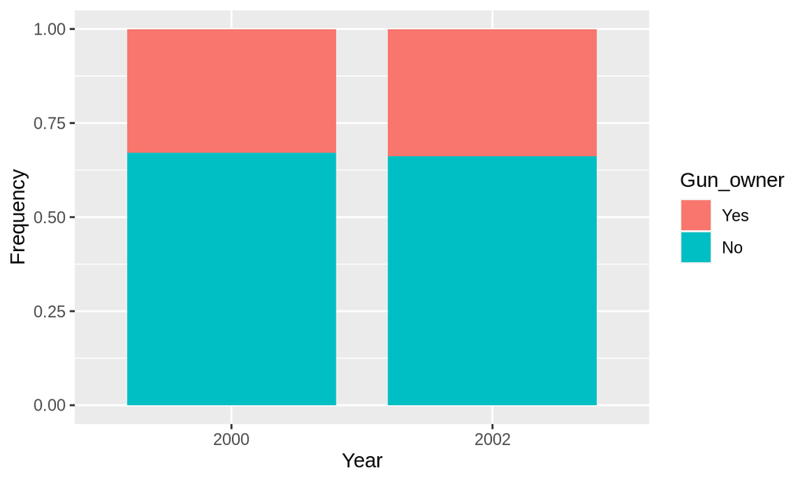

```r
# Create a dataframe using the frequency contingency table.
dftable <- data.frame(ftable)
colnames(dftable) <- c('Year', 'Gun_owner', 'Frequency')

# Bar chart.
ggplot(data = dftable, aes(x = Year, y = Frequency, fill = Gun_owner)) +
  geom_bar(stat = 'identity', width = 0.8)
```

The chart reflects the earlier observation. In 2002, there is a slight increase in gun ownership. The difference is barely noticeable on the chart. We need to perform statistical inference in order to identify whether this difference is significant or not.

## 4. Statistical Inference

### 4.1 Statistical Method

Both variables are categorical. The variable **Year** has two levels i.e. 2000 and 2002. Similarly, the variable **owngun** has two levels, namely “Yes” and “No”.

Therefore the method of inference must be for checking the difference of two proportions. The proportions would be gun ownership in the two years i.e. the proportion of people that answered *Yes* to the variable **owngun** in the two years.**Year** is the grouping variable. **owngun** is the response variable.

Statistical test is to check whether the difference between these proportions in year 2000 and 2002 can be explained by the sampling variability. The method is based on the standard normal distribution (i.e. Z distribution).

We calculate a cut-off *Z* value as follows:
$$Z = \frac {\text{point estimate} - \text{null value}} {SE}$$

The point estimate is the difference of the proportions obtained by the sample. Null value is the value set for the hull hypothesis. *SE* is the standard error. The P-value is obtained from a standard normal table by using the above *Z* cut-off value. The P-value is defined as the probability of obtaining the observed value for the point estimate or a more extreme value, given the null hypothesis is correct. If the P-value is less than the significance level (usually 0.05), the hull hypothesis is rejected in favor of the alternative hypothesis.

**Rationale for confidence interval**: A confidence interval represents a plausible range of values for the population parameter. Even though we are dealing with categorical variables, the proportions are numerical. Therefore, a confidence interval can be calculated as given below. *Z** is the critical *Z* value for the required significance level.

Confidence interval is:
$$\text{point estimate} \pm Z^* SE$$

The calculation of the *SE* depends on whether we are trying to do a hypothesis test or calculate the confidence interval.

### 4.2 Hypotheses

The parameter of interest is
$$P_{2002} - P_{2000}$$
.

The point estimate (based on the sample) is:
$$( \hat{P}_{2002} - \hat{P}_{2000} )$$

### 4.3 Conditions

- Independence
  - Within groups: Samples were obtained randomly. Only one person from each household. Sapling was done without replacement. But the sample size is much lower than the U.S. adult population (i.e. n < 10% of U.S. population). Therefore independence is assured.
  - Between groups: This is not a paired sample. Therefore each observation is independent of others.
- Sample size and skew: According to the contingency table (ctable) created above, both “Yes” and “No” levels have counts higher than 10 for both years. Therefore, this condition is satisfied.

All conditions are satisfied by the data set. Therefore, a theoretical approach is possible.

### 4.4 Inference and Interpretation

#### 4.4.1 Confidence Interval

A 95% confidence interval is calculated.

```r
inference(data = projData, y = owngun, x = year, statistic = "proportion",
          success = "Yes", method = "theoretical", alternative = "greater",
          type = "ci", order = c(2002,2000))
```

```
## Response variable: categorical (2 levels, success: Yes)
## Explanatory variable: categorical (2 levels)
## n_2002 = 915, p_hat_2002 = 0.3388
## n_2000 = 1834, p_hat_2000 = 0.3288
## 95% CI (2002 - 2000): (-0.0274 , 0.0475)
```

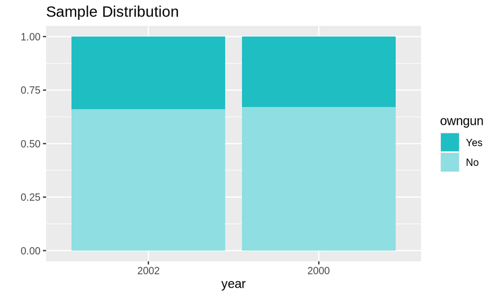

The null value is 0. It is clear that the calculated interval includes the null value. Therefore, it is clear that we will fail to reject the null hypothesis. This will be obvious based on the P-value calculated in the next section.

#### 4.4.2 Hypothesis Test

The chosen significance level is 0.05.

```r
inference(data = projData, y = owngun, x = year, statistic = "proportion",
          success = "Yes", method = "theoretical", alternative = "greater",
          type = "ht", order = c(2002,2000))
```

```
## Response variable: categorical (2 levels, success: Yes)
## Explanatory variable: categorical (2 levels)
## n_2002 = 915, p_hat_2002 = 0.3388
## n_2000 = 1834, p_hat_2000 = 0.3288
## H0: p_2002 =  p_2000
## HA: p_2002 > p_2000
## z = 0.525
## p_value = 0.2998
```

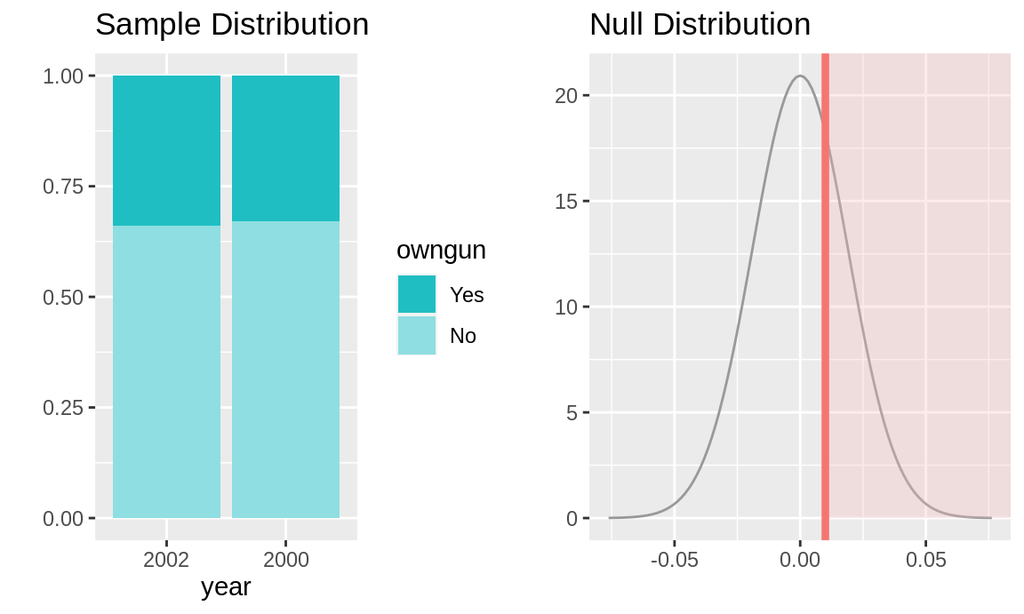

The critical Z value is 0.525 and the corresponding P-value is 0.2998. This is much larger than the significance level 0.05. Therefore, we **fail to reject** the null hypothesis.

The difference observed for the gun ownership between the two years 2000 and 2002 is not statistically significant and can be explained by sampling variability.

### 4.5 Conclusion

There is no statistically significant difference (significance level = 0.05, n_2000 = 1834 and n_2002 = 915) in gun ownership in the U.S. population between 2000 and 2002. There appears to be no correlation between the **year** and **owngun** variables for the years considered.